# Food Delivery Time Prediction

Tria Rahmat Mauludin

2/25/2022

# Objective

- Determine the factor that impact the food delivery time
- Create model for predict/estimate the food delivery time

# Import Library

```r
library(dplyr)
library(tidyverse)
library(tidymodels)
```

# Import Data

```r
library(readxl)
train_data <- read_excel("./dataset/Data_Train.xlsx")
test_data <- read_excel("./dataset/Data_Test.xlsx")
head(train_data)
```

```
## # A tibble: 6 x 9
##   Restaurant Location   Cuisines Average_Cost Minimum_Order Rating Votes Reviews
##   <chr>      <chr>      <chr>    <chr>        <chr>         <chr>  <chr> <chr>
## 1 ID_6321    FTI Colle~ Fast Fo~ ₹200         ₹50           3.5    12    4
## 2 ID_2882    Sector 3,~ Ice Cre~ ₹100         ₹50           3.5    11    4
## 3 ID_1595    Mumbai Ce~ Italian~ ₹150         ₹50           3.6    99    30
## 4 ID_5929    Sector 1,~ Mughlai~ ₹250         ₹99           3.7    176   95
## 5 ID_6123    Rmz Cente~ Cafe, B~ ₹200         ₹99           3.2    521   235
## 6 ID_5221    Rmz Cente~ South I~ ₹150         ₹50           3.8    46    18
## # ... with 1 more variable: Delivery_Time <chr>
```

**Details:**

- `Restaurant` : ID Restaurant
- `Location` : Restaurant Location
- `Cuisines` : The type of food that offered by the restaurant
- `Average_Cost` : The average food price
- `Minimum_Order` : Minimum purchase
- `Rating` : The rating of the restaurant
- `Votes` : The number of votes for the restaurant
- `Reviews` : The number of review of the restaurant
- `Delivery_Time` : The time need for delivery

# Preprocess Data

```r
str(train_data)
```

```
## tibble [11,094 x 9] (S3: tbl_df/tbl/data.frame)
##  $ Restaurant   : chr [1:11094] "ID_6321" "ID_2882" "ID_1595" "ID_5929" ...
##  $ Location     : chr [1:11094] "FTI College, Law College Road, Pune" "Sector 3, Marathalli" "Mumbai Central" "Sector 1, Noida" ...
##  $ Cuisines     : chr [1:11094] "Fast Food, Rolls, Burger, Salad, Wraps" "Ice Cream, Desserts" "Italian, Street Food, Fast Food" "Mughlai, North Indian, Chinese" ...
##  $ Average_Cost : chr [1:11094] "₹200" "₹100" "₹150" "₹250" ...
##  $ Minimum_Order: chr [1:11094] "₹50" "₹50" "₹50" "₹99" ...
##  $ Rating       : chr [1:11094] "3.5" "3.5" "3.6" "3.7" ...
##  $ Votes        : chr [1:11094] "12" "11" "99" "176" ...
##  $ Reviews      : chr [1:11094] "4" "4" "30" "95" ...
##  $ Delivery_Time: chr [1:11094] "30 minutes" "30 minutes" "65 minutes" "30 minutes" ...
```

## Location

Find the unique location:

```r
unique(train_data$Location)
```

```
##  [1] "FTI College, Law College Road, Pune"
##  [2] "Sector 3, Marathalli"
##  [3] "Mumbai Central"
##  [4] "Sector 1, Noida"
##  [5] "Rmz Centennial, I Gate, Whitefield"
##  [6] "Delhi University-GTB Nagar"
##  [7] "Yerawada, Pune, Maharashtra"
##  [8] "Delhi Administration Flats, Timarpur"
##  [9] "Moulali, Kolkata"
## [10] "Dockyard Road, Mumbai CST Area"
## [11] "Pune University"
## [12] "Gora Bazar, Rajbari, North Dumdum, Kolkata"
## [13] "D-Block, Sector 63, Noida"
## [14] "Sector 14, Noida"
## [15] "Mico Layout, Stage 2, BTM Layout,Bangalore"
```

[output cut: 20 more lines]

From the result above, we will generalized the location by the city (the words after last comma).

- “Mumbai”, “Mumbai CST Area” , “Mumbai Central” -> “Mumbai”
- “Bangalore”, “Electronic City”, “Marathalli”, “Whitefield” -> “Bangalore”
- “India Gate”, “Delhi”, “Delhi University-GTB Nagar”, “Delhi Cantt.” , “Timarpur”, “Noida” -> “Delhi”
- “Gurgoan”, “Gurgaon” -> “Gurgaon”
- “Kolkata” -> “Kolkata”
- “Maharashtra”, “Pune”, “Pune University” -> “Maharashtra”
- “Hyderabad”, “Begumpet”, “Majestic” -> “Hyderabad”

Then, we will change the type into factor

## Cuisines

```r
unique(train_data$Cuisines)[1:10]
```

```
##  [1] "Fast Food, Rolls, Burger, Salad, Wraps"
##  [2] "Ice Cream, Desserts"
##  [3] "Italian, Street Food, Fast Food"
##  [4] "Mughlai, North Indian, Chinese"
##  [5] "Cafe, Beverages"
##  [6] "South Indian, North Indian, Chinese"
##  [7] "Beverages, Fast Food"
##  [8] "Chinese, Thai, Asian"
##  [9] "Mithai, Street Food"
## [10] "Fast Food, North Indian, Rolls, Chinese, Momos, Mughlai"
```

From result above, one delivery order can contained some types of cuisines. We will doing One-Hot Encoding for every cuisines type.

## Average Cost and Minimum Order

We will remove the string `\u20b9` and `,` in every data then change it to numeric type.

## Rating

We will convert as numeric. If the Rating is `NEW`, `Opening Soon`, `Temporarily Closed`, or `-` we will change to `NA`.

## Votes

We will convert as numeric.

## Reviews

We will convert as numeric.

## Delivery Times

We will remove string `minutes` then convert it to numeric

# Splitting Data

Splitting data into train_data and validation_data

```r
set.seed(100)

splitted <- initial_split(train_data, prop = 0.8, strata = 'Delivery_Time')
splitted
```

```
## <Analysis/Assess/Total>
## <8875/2219/11094>
```

# Pipeline Preprocessing using tidymodels

```r
# Function to transform Location into City
transform_location <- function(Location){
  if(Location %in% c("Mumbai", "Mumbai CST Area" , "Mumbai Central")){
    return ("Mumbai")
  } else if(Location %in% c("Bangalore", "Electronic City", "Marathalli", "Whitefield")){
    return("Bangalore")
  } else if(Location %in% c("India Gate", "Delhi", "Delhi University-GTB Nagar", "Delhi Cantt." , "Timarpur", "Noida")){
    return("Delhi")
  } else if(Location %in% c("Gurgoan", "Gurgaon")){
    return("Gurgaon")
  } else if(Location %in% c("Maharashtra", "Pune", "Pune University")){
    return("Maharashtra")
  } else if(Location %in% c("Hyderabad", "Begumpet", "Majestic")){
    return("Hyderabad")
  } else if(Location %in% c("Kolkata")){
    return("Kolkata")
  }
}

# Preprocess Pipeline
rec_regression <- recipe(Delivery_Time~., data = training(splitted)) %>%
  step_select(-Restaurant) %>%
  step_mutate(
    Location =  word(Location, -1, sep=",") %>% trimws() %>% sapply(function(x) transform_location(x)),
    Average_Cost = gsub('[\u20b9]|,', '', Average_Cost) %>% as.numeric(),
    Minimum_Order = gsub('[\u20b9]|,', '', Minimum_Order) %>% as.numeric(),
    Rating = as.character(Rating) %>% as.numeric(),
    Votes = as.character(Votes) %>% as.numeric(),
    Reviews = as.character(Reviews) %>% as.numeric(),
    Delivery_Time = gsub('[ minutes]', '', Delivery_Time) %>%  as.numeric()
  ) %>%
  step_dummy_extract(Cuisines, sep= ", ") %>%
  step_mutate_at(starts_with("Cuisines"), fn = function(x)(as.factor(x)), skip=TRUE) %>%
  step_select(-Cuisines_other) %>%
  step_naomit(everything()) %>%
  prep()

rec_classification <- rec_regression %>%
  step_mutate(Delivery_Time = as.factor(Delivery_Time)) %>%
  prep()
```

Create training and validation data

```r
data_train_reg <- juice(rec_regression)
data_train_cla <- juice(rec_classification)
head(data_train_reg)
```

```
## # A tibble: 6 x 106
##   Location    Average_Cost Minimum_Order Rating Votes Reviews Delivery_Time
##   <fct>              <dbl>         <dbl>  <dbl> <dbl>   <dbl>         <dbl>
## 1 Maharashtra          200            50    3.5    12       4            30
## 2 Bangalore            100            50    3.5    11       4            30
## 3 Bangalore            200            99    3.2   521     235            65
## 4 Bangalore            150            50    3.8    46      18            30
## 5 Mumbai               150            50    3.7   108      31            30
## 6 Delhi                100            50    3.9   110      26            30
## # ... with 99 more variables: Cuisines_Afghan <fct>, Cuisines_African <fct>,
## #   Cuisines_American <fct>, Cuisines_Andhra <fct>, Cuisines_Arabian <fct>,
## #   Cuisines_Asian <fct>, Cuisines_Assamese <fct>, Cuisines_Awadhi <fct>,
## #   Cuisines_Bakery <fct>, Cuisines_Bangladeshi <fct>, Cuisines_Bar.Food <fct>,
## #   Cuisines_BBQ <fct>, Cuisines_Belgian <fct>, Cuisines_Bengali <fct>,
## #   Cuisines_Beverages <fct>, Cuisines_Bihari <fct>, Cuisines_Biryani <fct>,
## #   Cuisines_Brazilian <fct>, Cuisines_Bubble.Tea <fct>, ...
```

```r
data_validation_reg <- bake(rec_regression, testing(splitted))
data_validation_cla <- bake(rec_classification, testing(splitted))
head(data_validation_cla)
```

```
## # A tibble: 6 x 106
##   Location Average_Cost Minimum_Order Rating Votes Reviews Delivery_Time
##   <fct>           <dbl>         <dbl>  <dbl> <dbl>   <dbl> <fct>
## 1 Delhi             250            99    3.7   176      95 30
## 2 Delhi             650            50    4    1731    1235 45
## 3 Mumbai            350            50    3.8   186      61 30
## 4 Delhi              50             0    3.8   184     128 45
## 5 Kolkata           100            50    3.6   353      53 30
## 6 Kolkata           100            50    3.7   159      46 30
## # ... with 99 more variables: Cuisines_Afghan <fct>, Cuisines_African <fct>,
## #   Cuisines_American <fct>, Cuisines_Andhra <fct>, Cuisines_Arabian <fct>,
## #   Cuisines_Asian <fct>, Cuisines_Assamese <fct>, Cuisines_Awadhi <fct>,
## #   Cuisines_Bakery <fct>, Cuisines_Bangladeshi <fct>, Cuisines_Bar.Food <fct>,
## #   Cuisines_BBQ <fct>, Cuisines_Belgian <fct>, Cuisines_Bengali <fct>,
## #   Cuisines_Beverages <fct>, Cuisines_Bihari <fct>, Cuisines_Biryani <fct>,
## #   Cuisines_Brazilian <fct>, Cuisines_Bubble.Tea <fct>, ...
```

Check if there is any `NA` value.

```r
any(is.na(data_train_reg))
```

```
## [1] FALSE
```

```r
any(is.na(data_train_cla))
```

```
## [1] FALSE
```

```r
any(is.na(data_validation_reg))
```

```
## [1] FALSE
```

```r
any(is.na(data_validation_cla))
```

```
## [1] FALSE
```

# EDA

## Time Distribution over Different Location

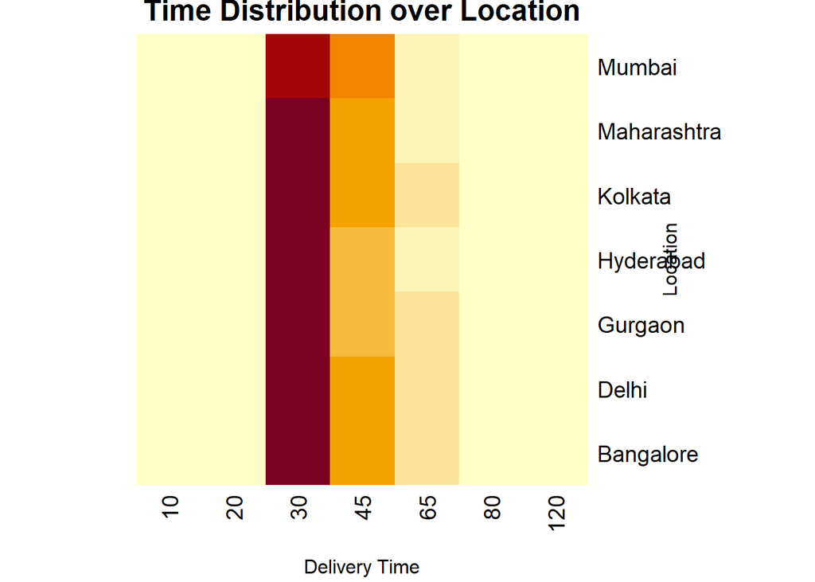

```r
xtabs(~Location+Delivery_Time, data = data_train_reg) %>%
  heatmap(Colv = NA,
          Rowv = NA,
          xlab = 'Delivery Time',
          ylab = 'Location',
          main = 'Time Distribution over Location')
```

## Time Distribution over Rating

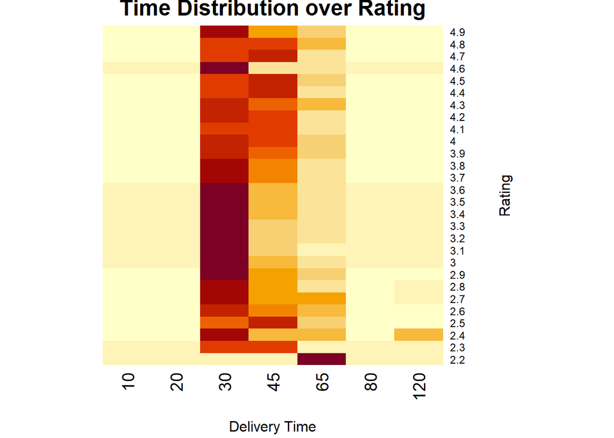

```r
xtabs(~Rating+Delivery_Time, data = data_train_reg) %>%
  heatmap(xlab='Delivery Time',
          ylab='Rating',
          Colv = NA,
          Rowv = NA,
          main = 'Time Distribution over Rating'
          )
```

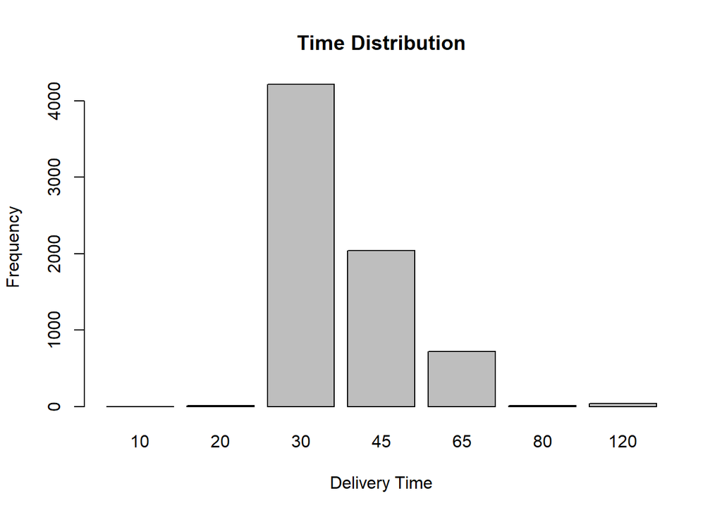

```r
table(data_train_reg$Delivery_Time) %>% barplot(xlab = 'Delivery Time',
                                                ylab = 'Frequency',
                                                main = 'Time Distribution')
```

# Modeling

## Regression Linear Model

```r
reg_model <- linear_reg(mode = "regression",
                       engine = "lm") %>%
             fit(formula=Delivery_Time ~ Location + Average_Cost + Minimum_Order + Rating + Votes + Reviews,
                 data=data_train_reg)
summary(reg_model$fit)
```

```
##
## Call:
## stats::lm(formula = Delivery_Time ~ Location + Average_Cost +
##     Minimum_Order + Rating + Votes + Reviews, data = data)
##
## Residuals:
##     Min      1Q  Median      3Q     Max
## -46.958  -7.498  -5.615   6.588  84.592
##
## Coefficients:
##                      Estimate Std. Error t value Pr(>|t|)
## (Intercept)         25.522320   1.559510  16.366  < 2e-16 ***
## LocationDelhi        0.614155   0.442457   1.388 0.165164
## LocationGurgaon      1.926297   0.704493   2.734 0.006267 **
## LocationHyderabad   -2.440392   0.689281  -3.540 0.000402 ***
## LocationKolkata      1.574066   0.760715   2.069 0.038565 *
## LocationMaharashtra -1.577684   0.509932  -3.094 0.001983 **
## LocationMumbai       0.418643   0.572217   0.732 0.464428
## Average_Cost         0.006989   0.001264   5.528 3.35e-08 ***
## Minimum_Order        0.137750   0.008018  17.181  < 2e-16 ***
## Rating               0.875584   0.414475   2.113 0.034678 *
## Votes                0.009289   0.000998   9.308  < 2e-16 ***
## Reviews             -0.011826   0.001762  -6.712 2.07e-11 ***
## ---
## Signif. codes:  0 '***' 0.001 '**' 0.01 '*' 0.05 '.' 0.1 ' ' 1
##
## Residual standard error: 12.48 on 7031 degrees of freedom
## Multiple R-squared:  0.09305,    Adjusted R-squared:  0.09163
## F-statistic: 65.58 on 11 and 7031 DF,  p-value: < 2.2e-16
```

## Multinomial Classification

```r
library(nnet)
multi_model <- multinom_reg(mode = "classification",
                            engine = "nnet") %>%
                fit(formula=Delivery_Time ~ .,
                  data=data_train_cla, size = 10, maxit=100)
```

## Random Forest

```r
set.seed(190)
rf_model <- rand_forest(mode = "classification",
                        engine = "ranger",
                        mtry = 5,
                        trees = 100) %>%
            fit(Delivery_Time ~ ., data = data_train_cla)
```

# Model Evaluation

## Regression

```r
result <- data_validation_reg %>%
  select(Delivery_Time) %>%
  bind_cols(predict(reg_model, new_data = data_validation_reg))

library(MLmetrics)
MAPE(result$Delivery_Time, result$.pred)
```

```
## [1] 0.2384645
```

## Neural Network

```r
data_train_cla %>%
  select(Delivery_Time) %>%
  bind_cols(predict(multi_model, new_data=data_train_cla)) %>%
  accuracy(truth = Delivery_Time, .pred_class)
```

```
## # A tibble: 1 x 3
##   .metric  .estimator .estimate
##   <chr>    <chr>          <dbl>
## 1 accuracy multiclass     0.649
```

```r
data_validation_cla %>%
  select(Delivery_Time) %>%
  bind_cols(predict(multi_model, new_data=data_validation_cla)) %>%
  accuracy(truth = Delivery_Time, .pred_class)
```

```
## # A tibble: 1 x 3
##   .metric  .estimator .estimate
##   <chr>    <chr>          <dbl>
## 1 accuracy multiclass     0.633
```

## Random Forest

```r
data_train_cla %>%
  select(Delivery_Time) %>%
  bind_cols(predict(rf_model, new_data=data_train_cla)) %>%
  accuracy(truth = Delivery_Time, .pred_class)
```

```
## # A tibble: 1 x 3
##   .metric  .estimator .estimate
##   <chr>    <chr>          <dbl>
## 1 accuracy multiclass     0.733
```

```r
data_validation_cla %>%
  select(Delivery_Time) %>%
  bind_cols(predict(rf_model, new_data=data_validation_cla)) %>%
  accuracy(truth = Delivery_Time, .pred_class)
```

```
## # A tibble: 1 x 3
##   .metric  .estimator .estimate
##   <chr>    <chr>          <dbl>
## 1 accuracy multiclass     0.678
```